# Assignment 2: Data visualization

Tamas Nagy

You will have to create 3 plots based on the datasets and instructions detailed below. You will find the plots themeselves in the `assignments/assignment_2_plots`. Your task is to write the code that will reproduce the plots as closely as possible.

# Skills needed to solve this assignment

- Using R and RStudio, reading data
- Reporting using RMarkdown
- Using Git and Github (for submitting the task)
- Data manipulation (e.g. dplyr, tidyr), and working with factors (forcats)
- Data visuzlization (ggplot2)

## Task 1: Climbing expeditions

The 2020-09-22 TidyTueday datasets are about climbing expeditions. From the three datasets, use the “expeditions”. Reproduce the plot below! Notice a few things:

- Use `forcats::fct_lump()` to get the 15 most frequent peaks, and drop the “Other” category.
- The bars are ordered by the sum of all expeditions (use `fct_reorder()`).
- The bar colors use the viridis palette and light theme.

```r
# Reading the data
expeditions <- readr::read_csv('https://raw.githubusercontent.com/rfordatascience/tidytuesday/master/data/2020/2020-09-22/expeditions.csv')
# Getting the 15 most frequent peaks
expeditions <- expeditions %>%
  mutate(peak_name_15 = fct_lump_n(peak_name, 15)) %>%
  count(peak_name_15, season, sort = TRUE)

# Excluding the "other" category
expeditions <- expeditions %>%
  filter(!(peak_name_15 == "Other"))

# Creating a dataframe with the total count of expeditions per peak (called sum_n)
expeditions2 <- expeditions %>%
  group_by(peak_name_15) %>%
  summarise(sum_n = sum(n, na.rm = TRUE)) %>%
  ungroup()
# Reordering the peak names by the previously calculated total counts of expeditions
expeditions <- expeditions %>%
  left_join(expeditions2) %>%
  mutate(peak_name_15 = fct_reorder(peak_name_15, sum_n))
```

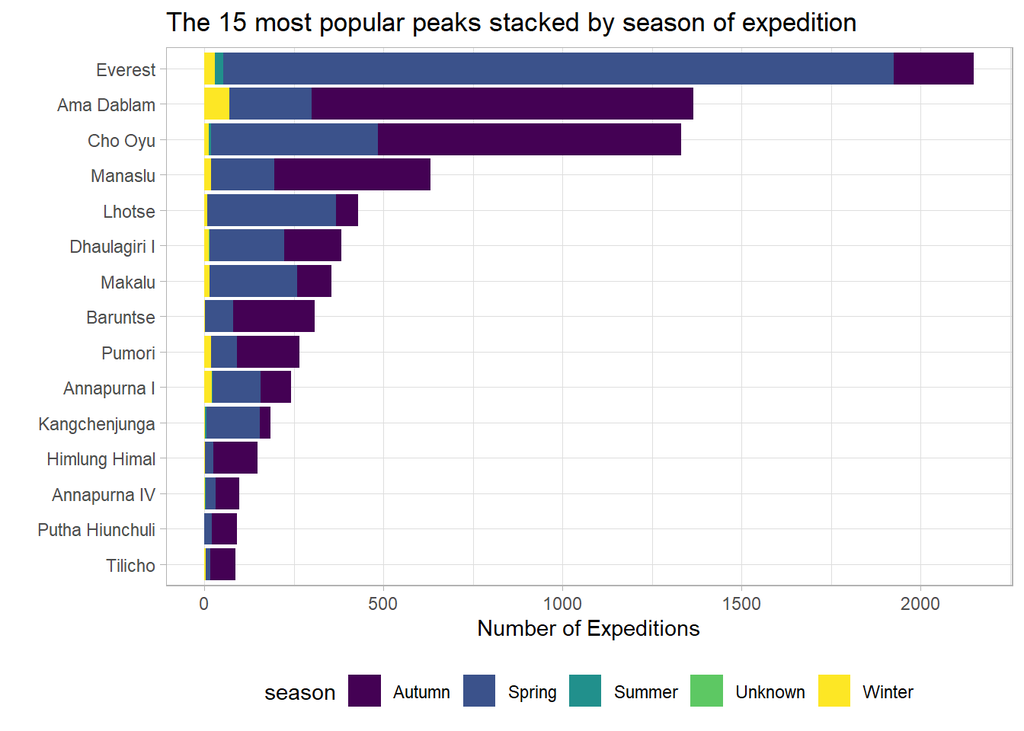

## Task 2: PhDs awarded

The 2019-02-19 TidyTueday dataset is about phd-s awarded by year and field. There is only one dataset, it is called `phd_by_field`. Reproduce the plot below!

```r
# Reading the data
phd_field <- readr::read_csv("https://raw.githubusercontent.com/rfordatascience/tidytuesday/master/data/2019/2019-02-19/phd_by_field.csv")
```

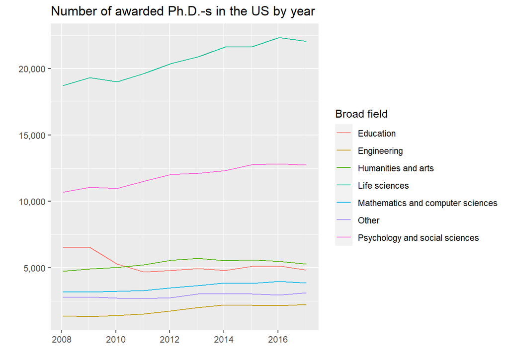

```r
# Selecting the variables needed for the plot, then grouping by broad field and year, while summing up the number of PhDs
phd_field_selected <- phd_field %>%
 select(broad_field, n_phds, year) %>%
 group_by(broad_field, year) %>%
 summarize(sum_n_phds = sum(n_phds, na.rm=TRUE)) %>%
 ungroup()
# Converting year to date format
phd_field_selected$year <- as.Date(as.character(phd_field_selected$year), "%Y")
```

## Task 3: Commute in the US

The 2019-11-05 TidyTueday dataset is about commuting to work in each city in the US by bike or on foot. There is only one dataset, it is called `commute`. Reproduce the plot below!

Notes:

```r
# Reading the data
commute_mode <- readr::read_csv("https://raw.githubusercontent.com/rfordatascience/tidytuesday/master/data/2019/2019-11-05/commute.csv")
# Selecting the region, abbreviated state, mode of transport, and number of commuters variables
commute_mode_selected <- commute_mode %>% select(state_abb, mode, state_region, n)

# Grouping by region, abbreviated state and mode of transport, while summing up the number of commuters
commute_mode_selected <- commute_mode_selected %>%
     group_by(state_region, state_abb, mode) %>%
     summarize(sum_n = sum(n, na.rm = TRUE)) %>%
     ungroup()
# Transforming the column "mode" into separate "bicycle" and walk "columns" using the variable number of commuters (sum_n)
commute_mode_selected <- pivot_wider(commute_mode_selected, names_from = "mode", values_from = "sum_n")
```

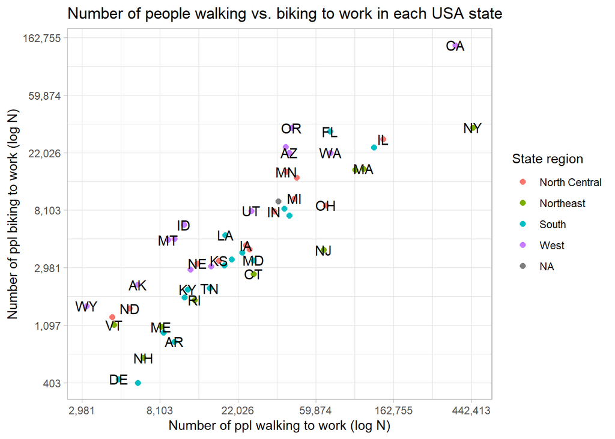